# Lab 2

Amritpal Sandhu, Collaborator: Elise Gonzales

2023-01-24

Today we will be continuing the pumpkin case study from last week. We will be using the data that you cleaned and split last time (pumpkins_train) and will be comparing our results today to those you have already obtained, so open and run your Lab 1 .Rmd as a first step so those objects are available in your Environment (unless you created an R Project last time, in which case, kudos to you!).

Polynomial regression is still linear regression, so our model specification looks similar to before.

```r
# Create a model specification called poly_spec
poly_spec <- linear_reg() %>%
  set_engine("lm") %>%
  set_mode("regression")
```

```r
# Bundle recipe and model specification into a workflow
poly_df <- workflow() %>%
  add_recipe(poly_pumpkins_recipe) %>%
  add_model(poly_spec)
```

Question 2: fit a model to the pumpkins_train data using your workflow and assign it to poly_wf_fit

```r
# Create a model using the workflow
poly_wf_fit <- poly_df %>%
  fit(data = pumpkins_train)
```

```
## ══ Workflow [trained] ══════════════════════════════════════════════════════════
## Preprocessor: Recipe
## Model: linear_reg()
##
## ── Preprocessor ────────────────────────────────────────────────────────────────
## 2 Recipe Steps
##
## • step_integer()
## • step_poly()
##
## ── Model ───────────────────────────────────────────────────────────────────────
##
## Call:
## stats::lm(formula = ..y ~ ., data = data)
##
## Coefficients:
##    (Intercept)  package_poly_1  package_poly_2
##          27.97          103.86         -110.91
```

```r
# Make price predictions on test data
poly_results <- poly_wf_fit %>% predict(new_data = pumpkins_test) %>%
  bind_cols(pumpkins_test %>% select(c(package, price))) %>%
  relocate(.pred, .after = last_col())

# Print the results
poly_results %>% slice_head(n = 5)
```

```
## # A tibble: 5 × 3
##   package              price .pred
##   <chr>                <dbl> <dbl>
## 1 1 1/9 bushel cartons  13.6  15.1
## 2 1 1/9 bushel cartons  16.4  15.1
## 3 1 1/9 bushel cartons  16.4  15.1
## 4 1 1/9 bushel cartons  13.6  15.1
## 5 1 1/9 bushel cartons  15.5  15.1
```

Now let’s evaluate how the model performed on the test_set using yardstick::metrics().

```r
metrics(data = poly_results, truth = price, estimate = .pred)
```

```
## # A tibble: 3 × 3
##   .metric .estimator .estimate
##   <chr>   <chr>          <dbl>
## 1 rmse    standard       4.72
## 2 rsq     standard       0.777
## 3 mae     standard       3.16
```

```r
metrics(data = lm_results, truth = price, estimate = .pred)
```

```
## # A tibble: 3 × 3
##   .metric .estimator .estimate
##   <chr>   <chr>          <dbl>
## 1 rmse    standard       7.23
## 2 rsq     standard       0.495
## 3 mae     standard       5.94
```

Question 3: How do the performance metrics differ between the linear model from last week and the polynomial model we fit today? Which model performs better on predicting the price of different packages of pumpkins?

**The polynomial regression is a better fit compared to the linear regression model and it also performs better. The rmse (root mean square error) describes the standard deviation of difference between predicted and observed values so the lower value in the polynomial regression means there are less errors and it is a better fit. For the rsq or coefficient of determination, values closer to 0 means the there is no relationship and values closer to 1 means there is a strong relationship and since the polynomial regression has a value closer to 1, it performs better at predicting the price.**

Let’s visualize our model results. First prep the results by binding the encoded package variable to them.

```r
# Bind encoded package column to the results
poly_results <- poly_results %>%
  bind_cols(package_encode %>%
              rename(package_integer = package)) %>%
  relocate(package_integer, .after = package)


# Print new results data frame
poly_results %>%
  slice_head(n = 5)
```

```
## # A tibble: 5 × 4
##   package              package_integer price .pred
##   <chr>                          <dbl> <dbl> <dbl>
## 1 1 1/9 bushel cartons               0  13.6  15.1
## 2 1 1/9 bushel cartons               0  16.4  15.1
## 3 1 1/9 bushel cartons               0  16.4  15.1
## 4 1 1/9 bushel cartons               0  13.6  15.1
## 5 1 1/9 bushel cartons               0  15.5  15.1
```

OK, now let’s take a look!

Question 4: Create a scatter plot that takes the poly_results and plots package vs. price. Then draw a line showing our model’s predicted values (.pred). Hint: you’ll need separate geoms for the data points and the prediction line.

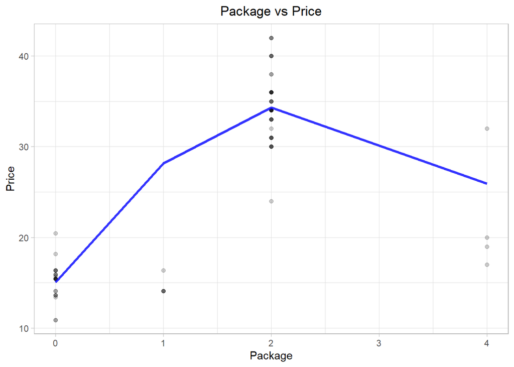

```r
# Make a scatter plot of the results
poly_results %>%
  ggplot(mapping = aes(x = package_integer, y = price)) +
   geom_point(size = 1.6, alpha = .2) +
   # Overlay a line of best fit
   geom_line(aes(y = .pred), color = "blue", size = 1.2, alpha = .8) +
   labs(x = "Package", y = "Price", title = "Package vs Price") + theme(plot.title = element_text(hjust = 0.5))
```

You can see that a curved line fits your data much better.

Question 5: Now make a smoother line by using geom_smooth instead of geom_line and passing it a polynomial formula like this: geom_smooth(method = lm, formula = y ~ poly(x, degree = 3), color = “midnightblue”, size = 1.2, se = FALSE)

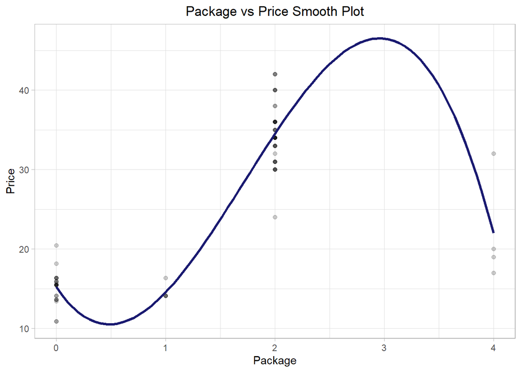

```r
# Make a smoother scatter plot
poly_results %>%
  ggplot(mapping = aes(x = package_integer, y = price)) +
   geom_point(size = 1.6, alpha = .2) +
   # Overlay a geom_smooth line
   xlab("package") + geom_smooth(method = lm, formula = y ~ poly(x, degree = 3), color = "midnightblue", size = 1.2, se = FALSE) + labs(x = "Package", y = "Price", title = "Package vs Price Smooth Plot") + theme(plot.title = element_text(hjust = 0.5))
```

OK, now it’s your turn to go through the process one more time.

Additional assignment components : 6. Choose a new predictor variable (anything not involving package type) in this dataset.

```
## [1] "variety"    "city_name"  "package"    "low_price"  "high_price"
## [6] "date"       "day"        "month"      "price"
```

**My new predictor variable is variety.**

7. Determine its correlation with the outcome variable (price). (Remember we calculated a correlation matrix last week)

```r
# Calculate the correlation between pumpkin price and variety
cor(baked_pumpkins$variety, baked_pumpkins$price)
```

```
## [1] -0.863479
```

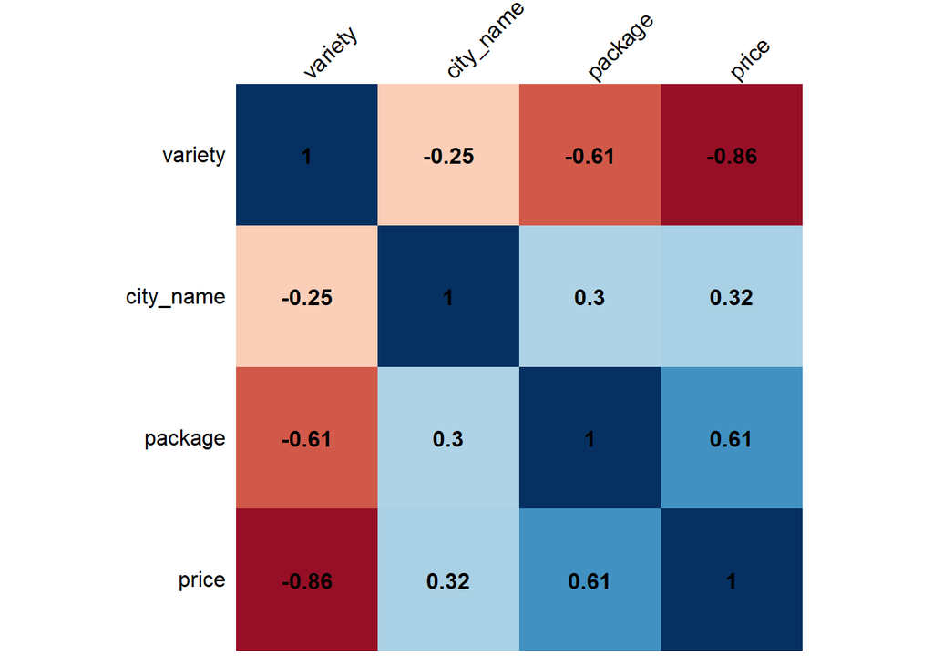

```r
# Obtain correlation matrix and drop low_price and high
corr_matrix <- cor(baked_pumpkins %>%
# Drop columns that are not really informative
  select(-c(low_price, high_price, month, day, date)))

# Make a correlation plot between the variables
corrplot(corr_matrix, method = "shade", shade.col = NA, tl.col = "black", tl.srt = 45, addCoef.col = "black", cl.pos = "n", order = "original")
```

8. Create and test a model for your new predictor:
- Create a recipe

```r
# Specify a recipe
pumpkins_recipe_variety <-
  recipe(price ~ variety, data = pumpkins_train) %>%
  step_integer(all_predictors(), zero_based = TRUE)
#%>% step_poly(all_predictors(), degree = 3)
```

- Build a model specification (linear or polynomial)

```r
# Create a model specification
poly_spec_var <- linear_reg() %>%
  set_engine("lm") %>%
  set_mode("regression")
```

- Bundle the recipe and model specification into a workflow

```r
# Bundle recipe and model spec into a workflow
poly_wf_var <- workflow() %>%
  add_recipe(pumpkins_recipe_variety) %>%
  add_model(poly_spec_var)
```

- Create a model by fitting the workflow

```r
# Create a model
poly_wf_fit_var <- poly_df %>%
  fit(data = pumpkins_train)
```

- Evaluate model performance on the test data

```r
# Make price predictions
poly_results_var <- pumpkins_test %>%
  select(c(variety, price)) %>%
  bind_cols(predictions)

# Print the results
#poly_results_var %>% slice_head(n = 10)

# Evaluate model performance
metrics(data = poly_results_var, truth = price, estimate = .pred)
```

```
## # A tibble: 3 × 3
##   .metric .estimator .estimate
##   <chr>   <chr>          <dbl>
## 1 rmse    standard       7.23
## 2 rsq     standard       0.495
## 3 mae     standard       5.94
```

- Create a visualization of model performance

```r
# Encode package column
encode_var <- pumpkins_recipe_variety %>%
  prep() %>%
  bake(new_data = pumpkins_test) %>%
  select(variety)

# Bind encoded package column to the results
 plot_results_var <- poly_results_var %>%
 bind_cols(encode_var %>%
               rename(variety_integer = variety)) %>%
  relocate(variety_integer, .after = variety)

# Print new results data frame
plot_results %>%
  slice_head(n = 5)
```

```
## # A tibble: 5 × 4
##   package              package_integer price .pred
##   <chr>                          <dbl> <dbl> <dbl>
## 1 1 1/9 bushel cartons               0  13.6  20.1
## 2 1 1/9 bushel cartons               0  16.4  20.1
## 3 1 1/9 bushel cartons               0  16.4  20.1
## 4 1 1/9 bushel cartons               0  13.6  20.1
## 5 1 1/9 bushel cartons               0  15.5  20.1
```

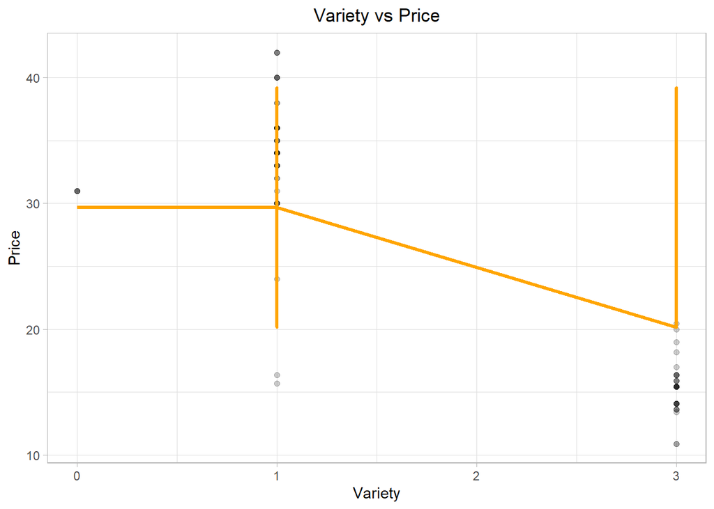

```r
# Make a scatter plot
plot_results_var %>%
  ggplot(mapping = aes(x = variety_integer, y = price)) +
   geom_point(size = 1.6, alpha = .2) +
   # Overlay a line of best fit
   geom_line(aes(y = .pred), color = "orange", size = 1.2) +
   labs(x = "Variety", y = "Price", title = "Variety vs Price") + theme(plot.title = element_text(hjust = 0.5))
```

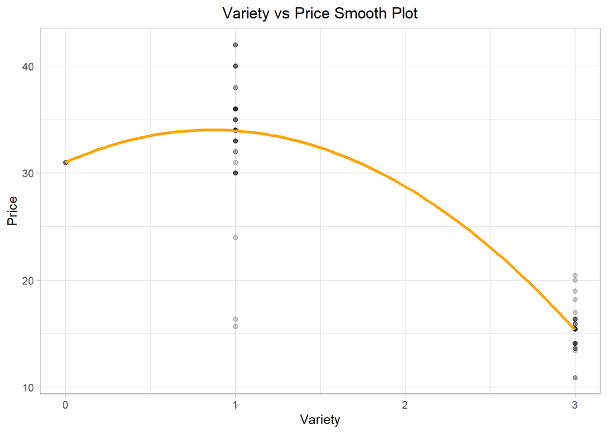

```r
# Graph with geom_smooth
plot_results_var %>%
  ggplot(mapping = aes(x = variety_integer, y = price)) +
   geom_point(size = 1.6, alpha = .2) +
   # Overlay a geom_smooth line
    geom_smooth(method = lm, formula = y ~ poly(x, degree = 2), color = "orange", size = 1.2, se = FALSE) + labs(x = "Variety", y = "Price", title = "Variety vs Price Smooth Plot") + theme(plot.title = element_text(hjust = 0.5))
```

Lab 2 due 1/24 at 11:59 PM